# DA5030 – Signature Project

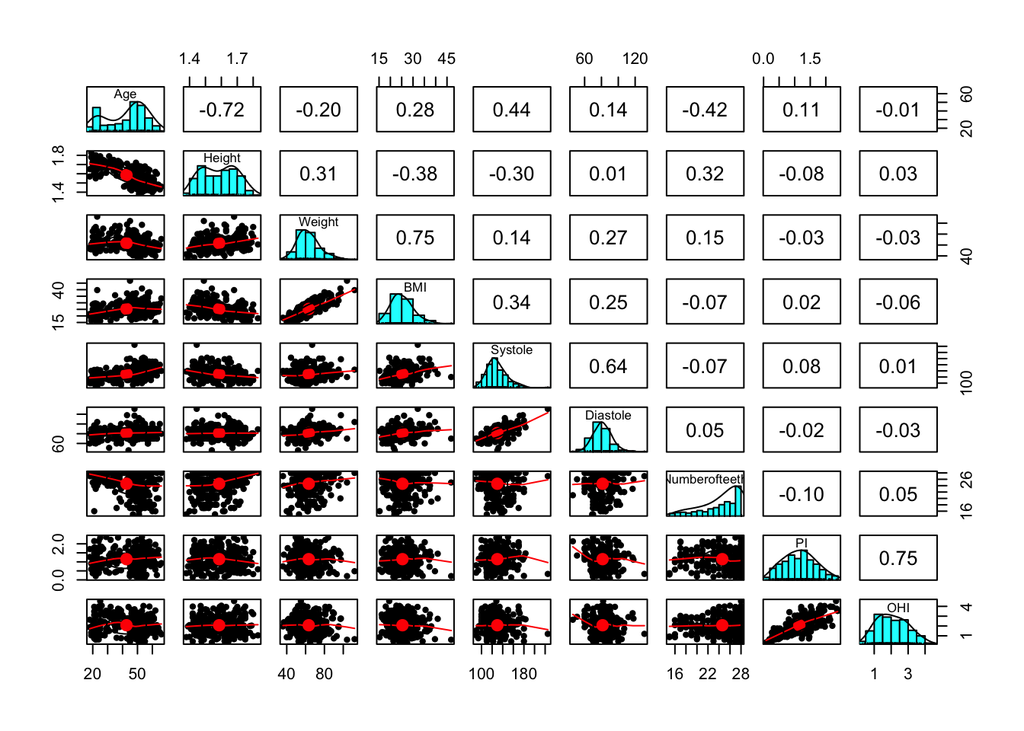

```r
#Use pairs.panel to display the distributions of each continuous variable and the coefficient between them.
OBT_pairPanel<-pairs.panels(OB_Teeth[-c(2,8:12,16:17)])
```

**5) Detection of outliers for continuous features**

```r
#The 27 outliers are detected from the boxplot. I decided to keep the outliers are they may contain important information
OBT_BoxP$out
```

```
##  [1] 104.00  97.00  97.50 112.00  95.00  93.00  95.00  38.05  46.84  37.48
## [11]  40.90  39.68  37.28 180.00 178.00 180.00 183.00 180.00 225.00 118.00
## [21]  46.00 112.00 131.00 117.00  51.00  15.00  15.00
```

**6) correlation/collinearity/chi-squared analysis**

- Below is a correlation matrix that display the correlations between each variables. correlation defines the strength of linear relationship between two variables, the larger the absolute value of correlation the stronger the relationship. Thus, the correlation that is >= 07 or <= -0.7 is considered a strong correlation.a strong correlation indicates a collinearity between the two variables.

```r
#correlation matrix to display coefficient between each variables
Correlation<-cor(OB_Teeth);Correlation
```

```
##                         Age         Sex       Height      Weight          BMI
## Age              1.00000000  0.80968589 -0.720332307 -0.20485840  0.282762513
## Sex              0.80968589  1.00000000 -0.764643234 -0.26718769  0.262961940
## Height          -0.72033231 -0.76464323  1.000000000  0.30663198 -0.382862323
## Weight          -0.20485840 -0.26718769  0.306631977  1.00000000  0.754079333
## BMI              0.28276251  0.26296194 -0.382862323  0.75407933  1.000000000
## Systole          0.43535467  0.28278902 -0.304141139  0.13893295  0.340575100
## Diastole         0.13961948  0.03995109  0.007609375  0.27372004  0.250068714
## Education        0.43735417  0.35947951 -0.506312561 -0.28711048  0.063117076
## Occupation      -0.68105000 -0.65808075  0.550352323  0.10461679 -0.268240058
## Smokingstatus   -0.46133362 -0.60379207  0.472881859  0.20161557 -0.128896693
## Alcoholstatus   -0.30150575 -0.32210435  0.232413157  0.12688325 -0.043689829
## DMstatus         0.09705907  0.10182747 -0.063321646 -0.05840463 -0.024454309
## Numberofteeth   -0.41765202 -0.37413293  0.322417468  0.14691361 -0.069991743
## PI               0.11205890  0.00513483 -0.080014723 -0.03401491  0.020268535
## OHI             -0.01199126 -0.22015389  0.034419787 -0.03090855 -0.057712011
## CAL_6mm          0.34714474  0.30298871 -0.267303027 -0.09856168  0.077451734
## CAL_morethan6mm  0.26386938  0.22898084 -0.190508079 -0.12886766 -0.006062366
##                      Systole      Diastole   Education  Occupation
## Age              0.435354666  0.1396194800  0.43735417 -0.68105000
## Sex              0.282789018  0.0399510874  0.35947951 -0.65808075
## Height          -0.304141139  0.0076093748 -0.50631256  0.55035232
## Weight           0.138932951  0.2737200423 -0.28711048  0.10461679
## BMI              0.340575100  0.2500687142  0.06311708 -0.26824006
## Systole          1.000000000  0.6380364481  0.21656017 -0.26225226
## Diastole         0.638036448  1.0000000000 -0.01962005 -0.13447259
## Education        0.216560167 -0.0196200492  1.00000000 -0.07845074
## Occupation      -0.262252257 -0.1344725910 -0.07845074  1.00000000
## Smokingstatus   -0.150296008  0.0439993315 -0.12135506  0.52755029
## Alcoholstatus   -0.106604443  0.0430055833 -0.16412924  0.21485149
## DMstatus         0.049921793  0.0211455962  0.01405391 -0.06184997
## Numberofteeth   -0.066101638  0.0494971439 -0.30499725  0.32154668
## PI               0.077997750 -0.0246215098  0.15932232 -0.06891051
## OHI              0.005023539 -0.0255471694  0.17484090  0.12182228
## CAL_6mm          0.181899382  0.0723642594  0.17309590 -0.25850002
## CAL_morethan6mm  0.108485046 -0.0007000439  0.17973284 -0.18792652
##                 Smokingstatus Alcoholstatus    DMstatus Numberofteeth
## Age               -0.46133362   -0.30150575  0.09705907   -0.41765202
## Sex               -0.60379207   -0.32210435  0.10182747   -0.37413293
## Height             0.47288186    0.23241316 -0.06332165    0.32241747
```

[output cut: 17 more lines]

```
## Height          -0.08001472  0.034419787 -0.26730303   -0.1905080789
## Weight          -0.03401491 -0.030908552 -0.09856168   -0.1288676628
## BMI              0.02026853 -0.057712011  0.07745173   -0.0060623660
## Systole          0.07799775  0.005023539  0.18189938    0.1084850459
## Diastole        -0.02462151 -0.025547169  0.07236426   -0.0007000439
## Education        0.15932232  0.174840896  0.17309590    0.1797328449
## Occupation      -0.06891051  0.121822275 -0.25850002   -0.1879265151
## Smokingstatus   -0.02159414  0.166956433 -0.14224385   -0.1011386110
## Alcoholstatus    0.02499168  0.030634817 -0.13540062   -0.1119694906
## DMstatus        -0.06896381 -0.053793134  0.07712815    0.0263541683
## Numberofteeth   -0.09923013  0.045884852 -0.27815452   -0.2561880679
## PI               1.00000000  0.749814295  0.31825076    0.2120694855
## OHI              0.74981430  1.000000000  0.23148456    0.1578751955
## CAL_6mm          0.31825076  0.231484555  1.00000000    0.6840045275
## CAL_morethan6mm  0.21206949  0.157875195  0.68400453    1.0000000000
```

- Lists of strong correlation, there are 5 strong correlations which are listed below. They are **sex & age (0.8096859),height & age(-0.7203323),sex & height(-0.7646432), weight & BMI(0.7540793), PI & OHI(0.7498143)**, and they are likely to be collinearity.

```r
Correlation[sapply(Correlation, function(x) any(x!=1& (x>=0.7|x<=-0.7)))]
```

```
##  [1]  0.8096859 -0.7203323  0.8096859 -0.7646432 -0.7203323 -0.7646432
##  [7]  0.7540793  0.7540793  0.7498143  0.7498143
```

- Verify the dependency of the 5 pairs have strong correlation using **chi-squared test**.

```r
chisq.test(OB_Teeth$Age,OB_Teeth$Sex);chisq.test(OB_Teeth$Age,OB_Teeth$Height);chisq.test(OB_Teeth$Height,OB_Teeth$Sex);chisq.test(OB_Teeth$Weight,OB_Teeth$BMI);chisq.test(OB_Teeth$PI,OB_Teeth$OHI)
```

```
##
##  Pearson's Chi-squared test
##
## data:  OB_Teeth$Age and OB_Teeth$Sex
## X-squared = 210.23, df = 48, p-value < 2.2e-16
```

```
##
##  Pearson's Chi-squared test
##
## data:  OB_Teeth$Age and OB_Teeth$Height
## X-squared = 2501.4, df = 2592, p-value = 0.897
```

```
##
##  Pearson's Chi-squared test
##
## data:  OB_Teeth$Height and OB_Teeth$Sex
## X-squared = 190.85, df = 54, p-value < 2.2e-16
```

```
##
##  Pearson's Chi-squared test
##
## data:  OB_Teeth$Weight and OB_Teeth$BMI
## X-squared = 17603, df = 15768, p-value < 2.2e-16
```

```
##
##  Pearson's Chi-squared test
##
## data:  OB_Teeth$PI and OB_Teeth$OHI
## X-squared = 27264, df = 26425, p-value = 0.0001504
```

**- Out of 5 pairs that are tested, the dependency between height~age are not statistically significant (P value >0.05), and the other four sets are showing dependencies (p value <0.05). Therefore I will remove sex, weight, and PI in the Data Cleaning & Shaping section.**

**7) Evaluation of distribution**

```r
SWtestdat<-setNames(data.frame(matrix(ncol = 9, nrow = 0)), colnames(OB_Teeth[-c(2,8:12,16:17)]))
for (i in 1:ncol(OB_Teeth[-c(2,8:12,16:17)])){
  SWtestdat[1,i]<-shapiro.test(OB_Teeth[-c(2,8:12,16:17)][,i])$p

}
SWtestdat
```

|  | Age | Height | Weight | BMI | Systole | Diastole | Numberofteeth | PI | OHI |
| --- | --- | --- | --- | --- | --- | --- | --- | --- | --- |
| 1 | 1.660956e-11 | 1.115128e-06 | 4.99539e-06 | 2.308344e-05 | 9.691047e-08 | 9.759529e-06 | 2.438915e-14 | 0.02728687 | 0.001985395 |

**All the p values for the shapiro test are less than 0.05 which indicates all the variables are NOT normally distributed.**

## 3. Data Cleaning & Shaping

**1) Identification of missing values**

```r
#Identify all the NAs.
colSums(is.na(OB_Teeth))
```

```
##             Age             Sex          Height          Weight             BMI
##               0               0               0               0               0
##         Systole        Diastole       Education      Occupation   Smokingstatus
##               0               0               0               0               0
##   Alcoholstatus        DMstatus   Numberofteeth              PI             OHI
##               0               0               0               0               0
##         CAL_6mm CAL_morethan6mm
##               0               0
```

**- There is no missing value in the data frame.**

**2) Data imputation of missing data**

- There is no missing value in the original data, and I will randomly insert missing value to the data and imputing them.

```r
#creating a dataframe with missing values randomly assigned
set.seed(1234)
OB_NA<-as.data.frame(lapply(OB_Teeth, function(x) x[sample(c(TRUE, NA), prob = c(0.9, 0.1), size = length(x), replace = TRUE) ]))
colSums(is.na(OB_NA))
```

```
##             Age             Sex          Height          Weight             BMI
##              26              33              32              36              22
##         Systole        Diastole       Education      Occupation   Smokingstatus
##              22              19              25              27              28
##   Alcoholstatus        DMstatus   Numberofteeth              PI             OHI
##              28              31              21              33              28
##         CAL_6mm CAL_morethan6mm
##              28              34
```

- Impute missing **category value** with the most frequent value

```r
OB_NA_categorical<-OB_NA[-c(1,3:7,13:17)]
for (i in 1:ncol(OB_NA_categorical)){
 OB_NA_categorical[,i]<-ifelse(is.na(OB_NA_categorical[,i]),which.max(tabulate(match(OB_NA_categorical[,i], unique(OB_NA_categorical[,i],na.rm=T)))),OB_NA_categorical[,i])
}#insert the most frequent value to replace missing values
colSums(is.na(OB_NA_categorical))# all NAs in the categorical variables are imputed.
```

```
##           Sex     Education    Occupation Smokingstatus Alcoholstatus
##             0             0             0             0             0
##      DMstatus
##             0
```

- Impute missing **continuous value** with the mean

```r
OB_NA_continuous<-OB_NA[-c(2,8:12,16:17)]
for (h in 1:ncol(OB_NA_continuous)){
  OB_NA_continuous[,h]<-ifelse(is.na(OB_NA_continuous[,h]), mean(OB_NA_continuous[,h],na.rm=T),OB_NA_continuous[,h])
}#insert the mean to replace the missing value
colSums(is.na(OB_NA_continuous)) # all NAs in the continuous variables are imputed.
```

```
##           Age        Height        Weight           BMI       Systole
##             0             0             0             0             0
##      Diastole Numberofteeth            PI           OHI
##             0             0             0             0
```

- Combine the imputed data frames together

```r
OB_NARM<-cbind(OB_NA_continuous,OB_NA_categorical)#new dataframe with NA imputed.
colSums(is.na(OB_NARM)) #all NAs are imputed
```

```
##           Age        Height        Weight           BMI       Systole
##             0             0             0             0             0
##      Diastole Numberofteeth            PI           OHI           Sex
##             0             0             0             0             0
##     Education    Occupation Smokingstatus Alcoholstatus      DMstatus
##             0             0             0             0             0
```

**3) Normalization/standardization of feature values**

- As I am using naive bayes, decision tree, and RIPPER algorithm, normalization/standardization is not needed. I will perform normalization for the question purpose.

```r
#split data into 70/30
train.dat<-OB_Teeth[1:183,]
test.dat<-OB_Teeth[184:262,]

#create a function for min-max normalization for test data using the min and max of the train data
normalize_test <- function(x,y) {
    return((x - min(y)) / (max(y) - min(y)))
}

#apply the function to the continuous input features in the test set
test_norm<-as.data.frame(mapply(normalize_test, test.dat[-c(2,8:12,16:19)],train.dat[-c(2,8:12,16:19)]))
summary(test_norm)
```

```
##       Age              Height            Weight            BMI
##  Min.   :0.00000   Min.   :0.08889   Min.   :0.1184   Min.   :0.03291
##  1st Qu.:0.08333   1st Qu.:0.43889   1st Qu.:0.2566   1st Qu.:0.16598
##  Median :0.33333   Median :0.64444   Median :0.3553   Median :0.26994
##  Mean   :0.35469   Mean   :0.58115   Mean   :0.3812   Mean   :0.28642
##  3rd Qu.:0.61458   3rd Qu.:0.74444   3rd Qu.:0.4474   3rd Qu.:0.38354
##  Max.   :0.81250   Max.   :0.93333   Max.   :0.7763   Max.   :0.69747
##     Systole           Diastole       Numberofteeth           PI
##  Min.   :0.07407   Min.   :0.05882   Min.   :0.07692   Min.   :0.02609
##  1st Qu.:0.16296   1st Qu.:0.30000   1st Qu.:0.76923   1st Qu.:0.33696
##  Median :0.22963   Median :0.40000   Median :0.92308   Median :0.49130
##  Mean   :0.24885   Mean   :0.38868   Mean   :0.84518   Mean   :0.48310
##  3rd Qu.:0.31852   3rd Qu.:0.46471   3rd Qu.:1.00000   3rd Qu.:0.60435
##  Max.   :0.60741   Max.   :0.83529   Max.   :1.00000   Max.   :1.00000
##       OHI
##  Min.   :0.02607
##  1st Qu.:0.30213
##  Median :0.46919
##  Mean   :0.47888
##  3rd Qu.:0.65521
##  Max.   :0.86730
```

```r
#create a function for min-max normalization for train data
normalize_train <- function(x) {
    return((x - min(x)) / (max(x) - min(x)))
}

#apply the function to the continuous input features in the training set
train_norm <- as.data.frame(lapply(train.dat[-c(2,8:12,16:17)], normalize_train))
summary(train_norm)
```

```
##       Age             Height           Weight            BMI
##  Min.   :0.0000   Min.   :0.0000   Min.   :0.0000   Min.   :0.0000
##  1st Qu.:0.5208   1st Qu.:0.2000   1st Qu.:0.2368   1st Qu.:0.2237
##  Median :0.6458   Median :0.3778   Median :0.3289   Median :0.3193
##  Mean   :0.5816   Mean   :0.4047   Mean   :0.3507   Mean   :0.3335
##  3rd Qu.:0.7500   3rd Qu.:0.5944   3rd Qu.:0.4474   3rd Qu.:0.4153
##  Max.   :1.0000   Max.   :1.0000   Max.   :1.0000   Max.   :1.0000
##     Systole          Diastole      Numberofteeth          PI
##  Min.   :0.0000   Min.   :0.0000   Min.   :0.0000   Min.   :0.0000
##  1st Qu.:0.2222   1st Qu.:0.3412   1st Qu.:0.5385   1st Qu.:0.2935
##  Median :0.2963   Median :0.4000   Median :0.7692   Median :0.4391
##  Mean   :0.3145   Mean   :0.4276   Mean   :0.6927   Mean   :0.4573
##  3rd Qu.:0.3815   3rd Qu.:0.5176   3rd Qu.:0.9231   3rd Qu.:0.6152
##  Max.   :1.0000   Max.   :1.0000   Max.   :1.0000   Max.   :1.0000
##       OHI
##  Min.   :0.0000
##  1st Qu.:0.2346
##  Median :0.3791
##  Mean   :0.3896
##  3rd Qu.:0.5344
##  Max.   :1.0000
```

```r
test_norm<-cbind(test_norm,test.dat[-c(1,3:7,13:17)]) #combine the normalized continuous data with the categorical data for the test data.
train_norm<-cbind(train_norm,train.dat[-c(1,3:7,13:17)]) #combine the normalized continuous data with the categorical data for the train data
summary(test_norm); summary(train_norm)
```

```
##       Age              Height            Weight            BMI
##  Min.   :0.00000   Min.   :0.08889   Min.   :0.1184   Min.   :0.03291
##  1st Qu.:0.08333   1st Qu.:0.43889   1st Qu.:0.2566   1st Qu.:0.16598
##  Median :0.33333   Median :0.64444   Median :0.3553   Median :0.26994
##  Mean   :0.35469   Mean   :0.58115   Mean   :0.3812   Mean   :0.28642
##  3rd Qu.:0.61458   3rd Qu.:0.74444   3rd Qu.:0.4474   3rd Qu.:0.38354
##  Max.   :0.81250   Max.   :0.93333   Max.   :0.7763   Max.   :0.69747
##     Systole           Diastole       Numberofteeth           PI
##  Min.   :0.07407   Min.   :0.05882   Min.   :0.07692   Min.   :0.02609
##  1st Qu.:0.16296   1st Qu.:0.30000   1st Qu.:0.76923   1st Qu.:0.33696
##  Median :0.22963   Median :0.40000   Median :0.92308   Median :0.49130
##  Mean   :0.24885   Mean   :0.38868   Mean   :0.84518   Mean   :0.48310
##  3rd Qu.:0.31852   3rd Qu.:0.46471   3rd Qu.:1.00000   3rd Qu.:0.60435
##  Max.   :0.60741   Max.   :0.83529   Max.   :1.00000   Max.   :1.00000
##       OHI               Sex           Education   Occupation
##  Min.   :0.02607   Min.   :0.0000   Min.   :0   Min.   :0.000
##  1st Qu.:0.30213   1st Qu.:0.0000   1st Qu.:1   1st Qu.:1.000
##  Median :0.46919   Median :0.0000   Median :1   Median :3.000
##  Mean   :0.47888   Mean   :0.2405   Mean   :1   Mean   :1.962
##  3rd Qu.:0.65521   3rd Qu.:0.0000   3rd Qu.:1   3rd Qu.:3.000
##  Max.   :0.86730   Max.   :1.0000   Max.   :2   Max.   :3.000
##  Smokingstatus    Alcoholstatus        DMstatus
##  Min.   :0.0000   Min.   :0.00000   Min.   :0.00000
##  1st Qu.:0.0000   1st Qu.:0.00000   1st Qu.:0.00000
##  Median :0.0000   Median :0.00000   Median :0.00000
##  Mean   :0.3038   Mean   :0.05063   Mean   :0.01266
##  3rd Qu.:1.0000   3rd Qu.:0.00000   3rd Qu.:0.00000
##  Max.   :1.0000   Max.   :1.00000   Max.   :1.00000
```

```
##       Age             Height           Weight            BMI
##  Min.   :0.0000   Min.   :0.0000   Min.   :0.0000   Min.   :0.0000
##  1st Qu.:0.5208   1st Qu.:0.2000   1st Qu.:0.2368   1st Qu.:0.2237
##  Median :0.6458   Median :0.3778   Median :0.3289   Median :0.3193
##  Mean   :0.5816   Mean   :0.4047   Mean   :0.3507   Mean   :0.3335
##  3rd Qu.:0.7500   3rd Qu.:0.5944   3rd Qu.:0.4474   3rd Qu.:0.4153
##  Max.   :1.0000   Max.   :1.0000   Max.   :1.0000   Max.   :1.0000
##     Systole          Diastole      Numberofteeth          PI
##  Min.   :0.0000   Min.   :0.0000   Min.   :0.0000   Min.   :0.0000
##  1st Qu.:0.2222   1st Qu.:0.3412   1st Qu.:0.5385   1st Qu.:0.2935
##  Median :0.2963   Median :0.4000   Median :0.7692   Median :0.4391
##  Mean   :0.3145   Mean   :0.4276   Mean   :0.6927   Mean   :0.4573
##  3rd Qu.:0.3815   3rd Qu.:0.5176   3rd Qu.:0.9231   3rd Qu.:0.6152
##  Max.   :1.0000   Max.   :1.0000   Max.   :1.0000   Max.   :1.0000
##       OHI              Sex           Education       Occupation
##  Min.   :0.0000   Min.   :0.0000   Min.   :0.000   Min.   :0.00
##  1st Qu.:0.2346   1st Qu.:1.0000   1st Qu.:1.000   1st Qu.:1.00
##  Median :0.3791   Median :1.0000   Median :1.000   Median :1.00
##  Mean   :0.3896   Mean   :0.7541   Mean   :1.251   Mean   :1.35
##  3rd Qu.:0.5344   3rd Qu.:1.0000   3rd Qu.:2.000   3rd Qu.:2.00
##  Max.   :1.0000   Max.   :1.0000   Max.   :2.000   Max.   :3.00
##  Smokingstatus    Alcoholstatus        DMstatus
##  Min.   :0.0000   Min.   :0.00000   Min.   :0.00000
##  1st Qu.:0.0000   1st Qu.:0.00000   1st Qu.:0.00000
##  Median :0.0000   Median :0.00000   Median :0.00000
##  Mean   :0.1639   Mean   :0.07104   Mean   :0.01639
##  3rd Qu.:0.0000   3rd Qu.:0.00000   3rd Qu.:0.00000
##  Max.   :1.0000   Max.   :1.00000   Max.   :1.00000
```

**4) Dummy codes if required for algorithm**

- Remove Multicollinearity (sex, weight, and PI)

```r
OB_Teeth<-OB_Teeth[-c(2,4,14)]
```

- Bin the other continuous variables and coerce catagorical data to factors.**I will not use one-hot encoding (dummy variable) as it is unnecessary for the algorithms of my choice(naive bayes, decision tree, and RIPPER algorithm)**

```r
OBT_categorical<-OB_Teeth%>%
  mutate(AgeBins = cut(Age, breaks = c(min(Age)-1,34,52,max(Age)+1)),
        HeightBins=cut(Height, breaks = c(min(Height)-1,1.53,1.68,max(Height)+1)),
         BMIBins = cut(BMI, breaks = c(min(BMI)-1,18.5,24.9,29.9,max(BMI)+1)),
         NumberofteethBins = cut(Numberofteeth, breaks = c(min(Numberofteeth)-1,19,23,max(Numberofteeth)+1)),
        OHIBins = cut(OHI, breaks = c(min(OHI)-1,1.2,3.0,6.0)))
OBT_categorical[6:10] <- lapply(OBT_categorical[6:10], factor)
```

**5) Transformation of features to adjust distribution**

- Since all my variables are converted to categorical data for naive bayes, feature transformation is not needed. However, according to the Shapiro-Wilk test that was done in the (2.7 evaluation of distribution), all the variables are not normally distributed.The log, inverse, or square-root transformation can be done on each variables and use Shapiro-Wilk test to evaluate the P value, the transformation method with the the highest p value will be used.And last, Shapiro-Wilk test will be done on the transformed data to evaluate the effectiveness of the transformation.

**6) Feature engineering: new derived features**

**Categorize column 16 to 17 into the one target variable (severity of periodontitis) based on the following criteria**

- **mild periodontitis (1)** CAL ≥ 6 mm no more than 8 sites.
- **Moderate periodontitis (2)** CAL ≥ 6 mm at 9-18 sites.
- **Severe periodontitis (3)** CAL ≥ 6 mm more than 18 sites.

```r
OBT_categorical<-OBT_categorical%>%
    mutate(severity =
           ifelse(!(CAL_morethan6mm + CAL_6mm>8),
                  "1",
           ifelse(!(CAL_morethan6mm+CAL_6mm<9)& !(CAL_6mm + CAL_morethan6mm >18),
                  "2",
           ifelse(!(CAL_6mm + CAL_morethan6mm <19),
                 "3",
                 "NA"))))
OBT_categorical$severity<-as.factor(OBT_categorical$severity) #convert into factor
summary(OBT_categorical$severity)
```

```
##   1   2   3
## 205  32  25
```

```r
prop.table(table(OBT_categorical$severity))#the target variable has 78% of mild, 12% of moderate, and 9.5% of severe.
```

```
##
##          1          2          3
## 0.78244275 0.12213740 0.09541985
```

**Categorize Systole and Diastole into a blood pressure variable based on the following criteria**

- 1. normal (<120 systolic and <80 diastolic)(1),
- 2. elevated (120–129 systolic and <80 diastolic)(2)
- 3. stage 1 hypertension (130–139 systolic or 80–89diastolic)(3)
- 4. stage 2 hypertension (≥140 systolic or ≥90 diastolic)(4)

```r
OBT_categorical<-OBT_categorical%>%
    mutate(BP =
           ifelse(Systole<120 & Diastole<80,
                  "1",
           ifelse(!(Systole>129|Systole<120) & Diastole<80,
                  "2",
           ifelse(!(Systole>139|Systole<130) |!(Diastole<80|Diastole>89),
                 "3",
           ifelse(!(Systole<140)|!(Diastole<90),
                 "4",
                 "NA")))))
OBT_categorical$BP<-as.factor(OBT_categorical$BP)
summary(OBT_categorical$BP)
```

```
##   1   2   3   4
##  51  24 129  58
```

## 4. Model Construction

**1) Creation of training & validation subsets**

```r
#split the data into 70/30
set.seed(1234)
intraining<-createDataPartition(OBT_categorical$severity,p=0.7,list=F)
train<-OBT_categorical[intraining,]
test<-OBT_categorical[-intraining,]
dim(train);dim(test)
```

```
## [1] 185  21
```

```
## [1] 77 21
```

```r
prop.table(table(test$severity)) # the test set has good representation of the data. However, the data is imbalanced as the 78% are mild, 12% are moderate, and 9.5% are severe, and I will use hybrid Sampling after evaluate the accuracy of the classification.
```

```
##
##          1          2          3
## 0.79220779 0.11688312 0.09090909
```

**2) Creation of model A with proper data encoding– Naive Bayes**

```r
#train the Naive Bayes model
OBT_NBmodel <- NaiveBayes(severity~Education+Occupation+Smokingstatus+Alcoholstatus+DMstatus+BP+AgeBins+HeightBins+BMIBins+NumberofteethBins+OHIBins, data=train)
```

**3) Creation of model B with proper data encoding–decision Tree**

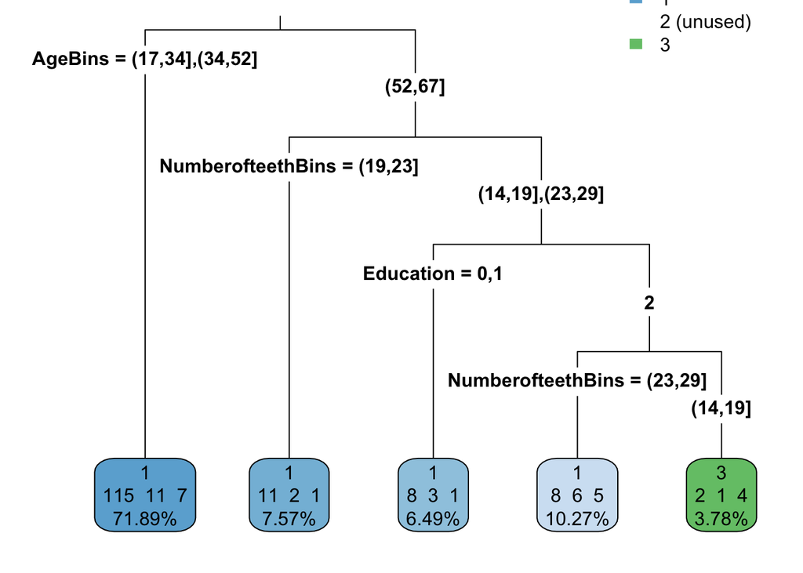

```r
#building the decision tree model
OBT_RTmodel <- rpart(severity~Education+Occupation+Smokingstatus+Alcoholstatus+DMstatus+BP+AgeBins+HeightBins+BMIBins+NumberofteethBins+OHIBins, data=train, control = rpart.control(cp = 0.0001))

#graph the model
rpart.plot(OBT_RTmodel,digits = 4, fallen.leaves = TRUE,
               type = 3, extra = 101)
```

**4) Creation of model C with proper data encoding –RIPPER**

```r
#building RIPPER model
OBT_RuleModel <- JRip(severity~Education+Occupation+Smokingstatus+Alcoholstatus+DMstatus+BP+AgeBins+HeightBins+BMIBins+NumberofteethBins+OHIBins, data=train)
```

## 5.Model Evaluation

**1) Evaluation of fit of models with holdout method**

- Naive Bayes

```r
#run the test data in the Naive Bayes model
OBT_NB_class <- predict(OBT_NBmodel, test[,-20])

#build a confusion matrix
CrossTable(OBT_NB_class$class, test[,20],
    prop.chisq = FALSE, prop.c = FALSE, prop.r = FALSE,
    dnn = c('predicted', 'actual'))
```

```
##
##
##    Cell Contents
## |-------------------------|
## |                       N |
## |         N / Table Total |
## |-------------------------|
##
##
## Total Observations in Table:  77
##
##
##              | actual
##    predicted |         1 |         2 |         3 | Row Total |
## -------------|-----------|-----------|-----------|-----------|
##            1 |        48 |         6 |         4 |        58 |
##              |     0.623 |     0.078 |     0.052 |           |
## -------------|-----------|-----------|-----------|-----------|
##            2 |         7 |         1 |         1 |         9 |
##              |     0.091 |     0.013 |     0.013 |           |
## -------------|-----------|-----------|-----------|-----------|
##            3 |         6 |         2 |         2 |        10 |
##              |     0.078 |     0.026 |     0.026 |           |
## -------------|-----------|-----------|-----------|-----------|
## Column Total |        61 |         9 |         7 |        77 |
## -------------|-----------|-----------|-----------|-----------|
##
##
```

```r
#accuracy= 0.662
0.623+0.013+0.026
```

```
## [1] 0.662
```

```r
#Precision = 0.2
2/(6+2+2)
```

```
## [1] 0.2
```

```r
#recall=0.286
2/(4+1+2)
```

```
## [1] 0.2857143
```

```r
#AUC = 0.577 is very low, which indicates no discrimination, the prediction is likely made by guessing
multiclass.roc(predictor=as.numeric(OBT_NB_class$class), response=test[,20])$auc
```

```
## Multi-class area under the curve: 0.5774
```

**The accuracy of the naive Bayes model is 66.2%, the precision is 20%, the recall is 28% with AUC of 57.7%**

- Decision tree

```r
#making the classification on the test data with decision tree model
OBT_RT_class <- predict(OBT_RTmodel, test, type = "class")

#build a confusion matrix
CrossTable(OBT_RT_class , test[,20],
    prop.chisq = FALSE, prop.c = FALSE, prop.r = FALSE,
    dnn = c('predicted', 'actual'))
```

```
##
##
##    Cell Contents
## |-------------------------|
## |                       N |
## |         N / Table Total |
## |-------------------------|
##
##
## Total Observations in Table:  77
##
##
##              | actual
##    predicted |         1 |         2 |         3 | Row Total |
## -------------|-----------|-----------|-----------|-----------|
##            1 |        61 |         9 |         6 |        76 |
##              |     0.792 |     0.117 |     0.078 |           |
## -------------|-----------|-----------|-----------|-----------|
##            3 |         0 |         0 |         1 |         1 |
##              |     0.000 |     0.000 |     0.013 |           |
## -------------|-----------|-----------|-----------|-----------|
## Column Total |        61 |         9 |         7 |        77 |
## -------------|-----------|-----------|-----------|-----------|
##
##
```

```r
#accuracy= 0.805
0.792+0.013
```

```
## [1] 0.805
```

```r
#Precision = 1
1/1
```

```
## [1] 1
```

```r
#recall=0.143
1/(6+1)
```

```
## [1] 0.1428571
```

```r
#AUC = 0.546 is also very low, which indicates no discrimination, the prediction is likely made by guessing
multiclass.roc(predictor=as.numeric(OBT_RT_class), response=test[,20])$auc
```

```
## Multi-class area under the curve: 0.5476
```

**The accuracy of the decision tree model is 80.5%, the precision is 100%, the recall is 14.3% with AUC of 54.8%**

- RIPPER

```r
#making the classification on the test data with RIPPER
OBT_Rule_class<-predict(OBT_RuleModel, test)

#build a confusion matrix
CrossTable(OBT_Rule_class, test[,20],
    prop.chisq = FALSE, prop.c = FALSE, prop.r = FALSE,
    dnn = c('predicted', 'actual'))
```

```
##
##
##    Cell Contents
## |-------------------------|
## |                       N |
## |         N / Table Total |
## |-------------------------|
##
##
## Total Observations in Table:  77
##
##
##              | actual
##    predicted |         1 |         2 |         3 | Row Total |
## -------------|-----------|-----------|-----------|-----------|
##            1 |        58 |         9 |         7 |        74 |
##              |     0.753 |     0.117 |     0.091 |           |
## -------------|-----------|-----------|-----------|-----------|
##            3 |         3 |         0 |         0 |         3 |
##              |     0.039 |     0.000 |     0.000 |           |
## -------------|-----------|-----------|-----------|-----------|
## Column Total |        61 |         9 |         7 |        77 |
## -------------|-----------|-----------|-----------|-----------|
##
##
```

```r
#accuracy= 0.753
#Precision = NA (there is TP)
#recall=NA (there is no TP)

#the AUC = 0.484 is very low, which indicates no discrimination, the prediction is likely made by guessing
multiclass.roc(predictor=as.numeric(OBT_Rule_class), response=test[,20])$auc
```

```
## Multi-class area under the curve: 0.4836
```

**2) Hybrid Sampling the imbalanced data**